# Final Project: Aircraft Accidents

Paul Garvey

May 18, 2018

In this tutorial we will explore the basics convered in CMSC320 using a single data source that is not only extensive, but has real world data that can answer some interesting questions regarding the common patterns found in aircraft incidents and maybe even the probability of an incident occuring to you! How Fun!

## Introduction

In today’s skies, there are flying machines of all different types that travel to new horizons. You have probably been in at least one of those types of aircraft in your life-time, but with so many different types out there, are their better options then the most common, an airplane? Unfortunatly, like all machines, aircraft are designed with safety in mind but accidents do occur, sometimes fatal. For this reason, we are going to look at records of aircraft incidents and try to discover what we can about when these incidents occur and their likelihood of resulting in a fatal incident.

It is important to note that not all incidents reported are the same. In fact, the FAA requires that all acts that could have resulted in a dangerous situation, such as engine failure, be reported to them. Engine failure may seem like a big deal for an aircraft, but it really depends on which aircraft, because different flight characteristics of different aircraft will determine the seriousness of such an event. For example: A typical Airplane with fixed wings is able to safely glide back down to earth and land safely with no damage to the airplane or the passangers. With this information, we will be able to determine safety by comparing incidents that resulted in fatalities compared to all of the incidents reported.

## Data Curation, Parsing, and Management

Before we can manipulate the data, we need to first scrape it! Luckily for us, the data that we are using comes from a fairly reputable source and is fairly clean.

The source is found here: https://www.kaggle.com/khsamaha/aviation-accident-database-synopses

As you can tell from the download, this is a .csv file or (Comma Separated Values file). In order to import into our Rmarkdown we will be using a function from tidyverse called `read_csv()` which will do just that, read the csv and make it into a dataframe.

```r
library(tidyverse)
library(broom)
library(knitr)
av_tab <- read_csv("AviationData.csv/AviationData.csv")
```

With this newly created data frame, we can further improve how the data is classified with in it, and tidy it up! For example, under Injury.Severity not only does the data display whether or not the incident was fatal, but it includes data that already exists in Total.Fatal.Injuries attribute. As a result, we are going to go ahead and remove that extra info, and factor the attribute like we will do for other attributes that should be classified in this way. Factoring the data lets the dataset know that this attribute contains a non-continuous variable that we may want to partition later. Lastly, we can fill in missing values in the table dealing with injuries so they quantify to 0.

```r
av_tab$Investigation.Type <- factor(av_tab$Investigation.Type)

av_tab$Injury.Severity <- sub("\\(\\d+\\)", "", av_tab$Injury.Severity)
av_tab$Injury.Severity <- factor(av_tab$Injury.Severity)

av_tab$Aircraft.Damage <- factor(av_tab$Aircraft.Damage)
av_tab$Aircraft.Category <- factor(av_tab$Aircraft.Category)
av_tab$Amateur.Built <- factor(av_tab$Amateur.Built)
av_tab$Engine.Type <- factor(av_tab$Engine.Type)
av_tab$Purpose.of.Flight <- factor(av_tab$Purpose.of.Flight)
av_tab$Weather.Condition <- factor(av_tab$Weather.Condition)
av_tab$Broad.Phase.of.Flight <- factor(av_tab$Broad.Phase.of.Flight)

av_tab$Total.Fatal.Injuries[is.na(av_tab$Total.Fatal.Injuries)] <- 0
av_tab$Total.Serious.Injuries[is.na(av_tab$Total.Serious.Injuries)] <- 0
av_tab$Total.Minor.Injuries[is.na(av_tab$Total.Minor.Injuries)] <- 0

av_tab
```

```
## # A tibble: 81,013 x 31
##    Event.Id  Investigation.T~ Accident.Number Event.Date Location  Country
##    <chr>     <fct>            <chr>           <date>     <chr>     <chr>
##  1 20171230~ Accident         WPR18LA058      2017-12-29 San Bern~ United~
##  2 20171229~ Accident         GAA18CA094      2017-12-28 Spearfis~ United~
##  3 20180102~ Accident         CEN18LA064      2017-12-28 Paulding~ United~
##  4 20171227~ Accident         GAA18CA096      2017-12-27 Upper La~ United~
##  5 20171228~ Accident         CEN18LA062      2017-12-27 Michigan~ United~
##  6 20171227~ Accident         WPR18CA059      2017-12-26 Santa An~ United~
##  7 20171226~ Accident         WPR18LA056      2017-12-25 Perris, ~ United~
##  8 20171224~ Accident         ERA18WA057      2017-12-24 Providen~ Turks ~
##  9 20171226~ Accident         ERA18LA059      2017-12-24 Union Mi~ United~
## 10 20171224~ Accident         CEN18FA061      2017-12-24 Bartow, ~ United~
## # ... with 81,003 more rows, and 25 more variables: Latitude <dbl>,
## #   Longitude <dbl>, Airport.Code <chr>, Airport.Name <chr>,
## #   Injury.Severity <fct>, Aircraft.Damage <fct>, Aircraft.Category <fct>,
## #   Registration.Number <chr>, Make <chr>, Model <chr>,
## #   Amateur.Built <fct>, Number.of.Engines <int>, Engine.Type <fct>,
## #   FAR.Description <chr>, Schedule <chr>, Purpose.of.Flight <fct>,
## #   Air.Carrier <chr>, Total.Fatal.Injuries <dbl>,
## #   Total.Serious.Injuries <dbl>, Total.Minor.Injuries <dbl>,
## #   Total.Uninjured <int>, Weather.Condition <fct>,
## #   Broad.Phase.of.Flight <fct>, Report.Status <chr>,
## #   Publication.Date <date>
```

Well that was not so hard! With our dataframe set up, we are now ready to begin analyzing the data and distinguish commonalities between the 81,000 recorded events

## Exploratory Data Analysis

Now that we have the data adequetly classified and properly tidied. Let’s visualize the data to get an idea of where we can go with it and see what patterns and trends that we can further analyze.

Let’s begin by looking to see which Phase of Flight can be considered most dangerous based on the data:

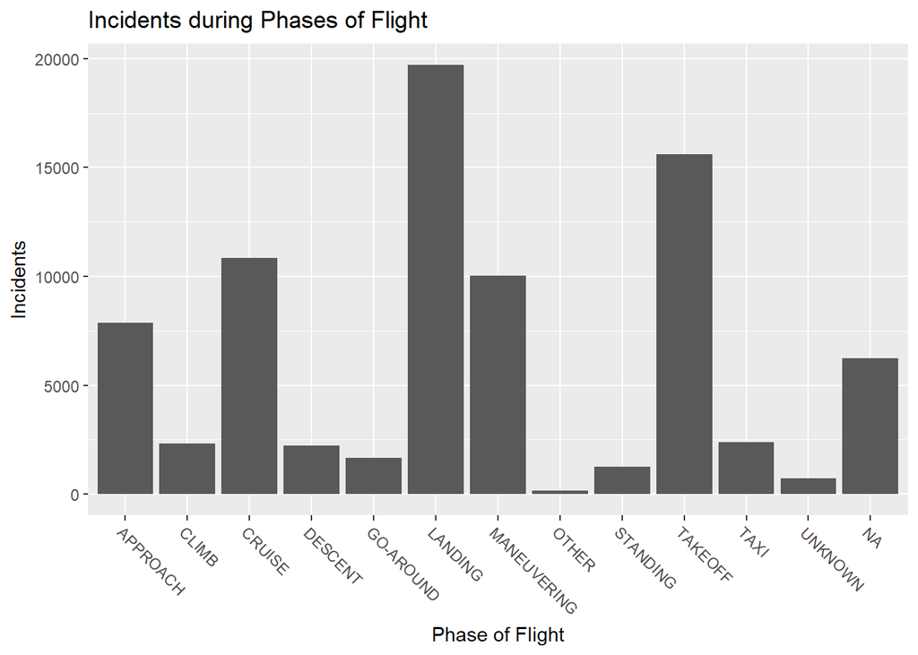

```r
av_tab %>%
  ggplot(aes(x=Broad.Phase.of.Flight)) +
  geom_bar() +
  labs(title="Incidents during Phases of Flight",
          x="Phase of Flight", y="Incidents") +
  theme(axis.text.x = element_text(angle = -45, hjust = 0))
```

Alright, that’s cool, clearly we can see that Landing and TakeOff are the two most dangerous phases of flight. This makes sense if you think about it. These events are transitional where the aircraft is transitioning from ground to sky or sky to ground. A lot must happen during these phases for things to go smoothly and it is more likely for a pilot to make a mistake at this time or an engine to fail as it pushed to work harder.

However, let’s shift focus on the fact that there are so many different kinds of aircraft with different characteristics. Is it possible to see that one type of aircraft is more dangerous than all others?

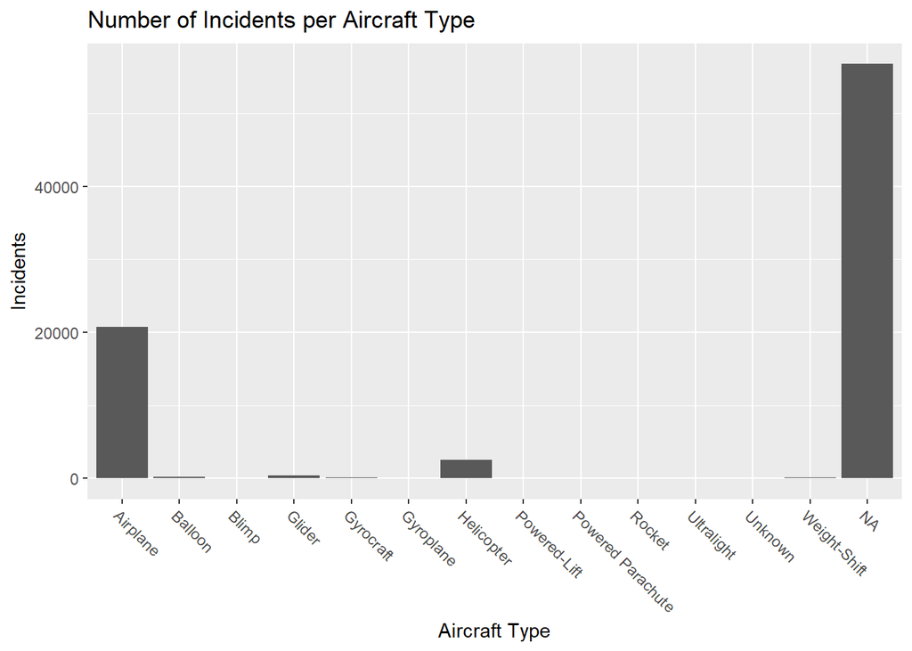

```r
av_tab %>%
  ggplot(aes(x=Aircraft.Category)) +
  geom_bar() +
  labs(title="Number of Incidents per Aircraft Type",
          x="Aircraft Type", y="Incidents") +
  theme(axis.text.x = element_text(angle = -45, hjust = 0))
```

Well, clearly this doesn’t tell us anything important or revolutionary, most of data is actually not classifed with an Aircraft Type. So that data is useless. However, we should be able to find some patterns with the rest of data considering their are more than 20,000+ records. We are going to filter out the Aircraft.Categories that we don’t care about, and try again.

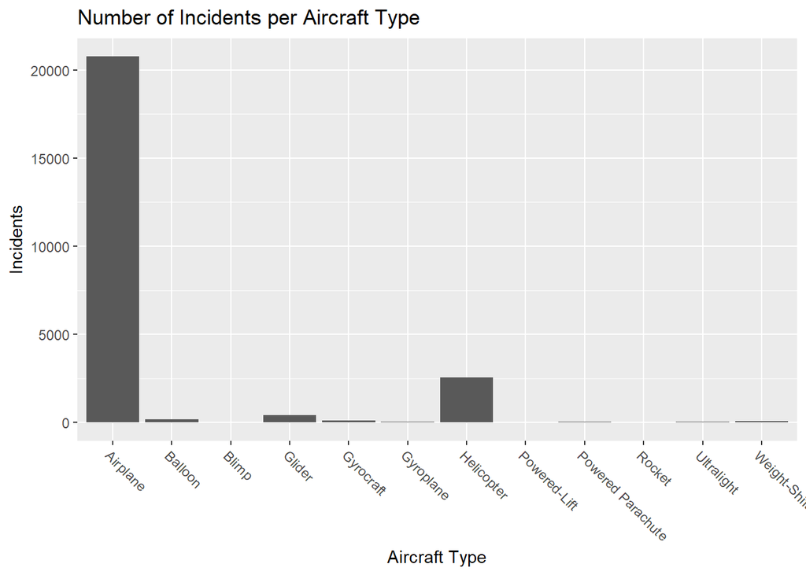

```r
av_cat_clean <- av_tab %>%
  filter(av_tab$Aircraft.Category != "NA", av_tab$Aircraft.Category != "Unknown")

av_cat_clean %>%
  ggplot(aes(x=Aircraft.Category)) +
  geom_bar() +
  labs(title="Number of Incidents per Aircraft Type",
          x="Aircraft Type", y="Incidents") +
  theme(axis.text.x = element_text(angle = -45, hjust = 0))
```

That’s better, but all this really tells us is that Airplanes have had more incidents reported then any other aircraft type, which makes sense as this is the most popular aircraft type. We need a better way of quantifying saftey and factoring more variables into the the data. Therefore we are going to create a new data frame to better quantify the data we have.

To do this we are going to simplify the date to just the year and then group the years into differet size periods that we will use for our analysis later on.

```r
av_cat_clean$Year <- sub("\\-\\d+\\-\\d+", "", av_cat_clean$Event.Date)
av_cat_clean$Year <- as.numeric(av_cat_clean$Year)

alt_av_tab <- av_cat_clean %>%
  filter(Injury.Severity != "Unavailable") %>%
  mutate(period=cut(Year, breaks = 10)) %>%
  group_by(Aircraft.Category, period) %>%
  count(Injury.Severity) %>%
  mutate(Total.Incidents=n)

alt_av_tab_2 <- av_cat_clean %>%
  filter(Year > "1980", Injury.Severity != "Unavailable") %>%
  mutate(period=cut(Year, breaks = 5)) %>%
  group_by(Aircraft.Category, period) %>%
  count(Injury.Severity) %>%
  mutate(Total.Incidents=n)

alt_av_tab_2 <- alt_av_tab_2 %>%
  select(Aircraft.Category,period,Injury.Severity,Total.Incidents)

alt_av_tab_2
```

```
## # A tibble: 70 x 4
## # Groups:   Aircraft.Category, period [36]
##    Aircraft.Category period      Injury.Severity Total.Incidents
##    <fct>             <fct>       <fct>                     <int>
##  1 Airplane          (1982,1989] Fatal                       604
##  2 Airplane          (1982,1989] Incident                    119
##  3 Airplane          (1982,1989] Non-Fatal                  2498
##  4 Airplane          (1989,1996] Fatal                        43
##  5 Airplane          (1989,1996] Incident                      5
##  6 Airplane          (1989,1996] Non-Fatal                    34
##  7 Airplane          (1996,2003] Fatal                       143
##  8 Airplane          (1996,2003] Incident                     59
##  9 Airplane          (1996,2003] Non-Fatal                   284
## 10 Airplane          (2003,2010] Fatal                       992
## # ... with 60 more rows
```

Ok, now we are talking! What we have now is a data frame that quantifies the number of incidents by their severity during 5 different time periods from 1980 to 2017. This puts us in a better position to manipulate the data and see trends across these years which is much more useful! Let’s visualize it!

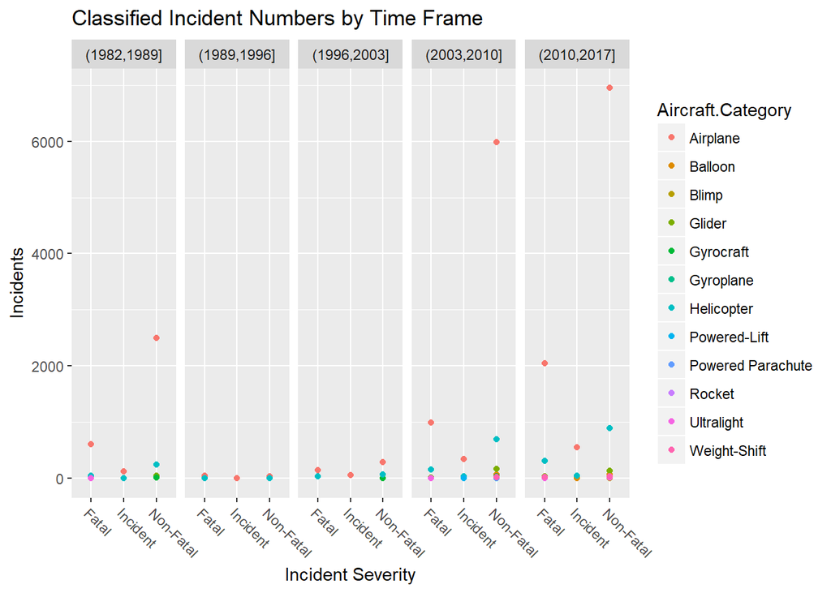

```r
alt_av_tab_2 %>%
ggplot(aes(x=Injury.Severity, y=Total.Incidents, color=Aircraft.Category)) +
    facet_grid(.~period) +
    geom_point() +
  labs(title="Classified Incident Numbers by Time Frame",
          x="Incident Severity", y="Incidents") +
    theme(axis.text.x = element_text(angle = -45, hjust = 0))
```

Not bad, some information can be observed, but the data is clearly skewed toward Airplanes, not allowing us to clearly compare between the safety of different Aircraft Types. We need to scale and center the data, thus standardizing it using the following formula.

$$z_i=\frac{x_i-\bar{x}}{sd(x)}$$

```r
standard_alt_av_tab <- alt_av_tab_2 %>%
  mutate(period_mean_incidents=mean(Total.Incidents), period_sd_incidents=sd(Total.Incidents), standard_incidents=(Total.Incidents-period_mean_incidents)/period_sd_incidents)

standard_alt_av_tab
```

```
## # A tibble: 70 x 7
## # Groups:   Aircraft.Category, period [36]
##    Aircraft.Category period      Injury.Severity Total.Incidents
##    <fct>             <fct>       <fct>                     <int>
##  1 Airplane          (1982,1989] Fatal                       604
##  2 Airplane          (1982,1989] Incident                    119
##  3 Airplane          (1982,1989] Non-Fatal                  2498
##  4 Airplane          (1989,1996] Fatal                        43
##  5 Airplane          (1989,1996] Incident                      5
##  6 Airplane          (1989,1996] Non-Fatal                    34
##  7 Airplane          (1996,2003] Fatal                       143
##  8 Airplane          (1996,2003] Incident                     59
##  9 Airplane          (1996,2003] Non-Fatal                   284
## 10 Airplane          (2003,2010] Fatal                       992
## # ... with 60 more rows, and 3 more variables:
## #   period_mean_incidents <dbl>, period_sd_incidents <dbl>,
## #   standard_incidents <dbl>
```

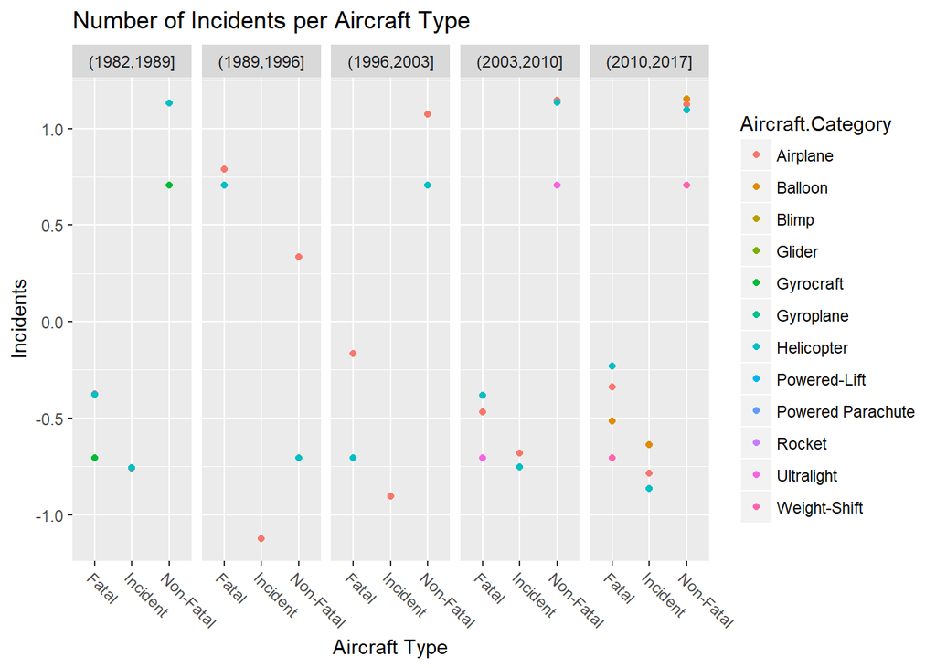

```r
standard_alt_av_tab %>%
ggplot(aes(x=Injury.Severity, y=standard_incidents, color=Aircraft.Category)) +
    facet_grid(.~period) +
    geom_point() +
  labs(title="Number of Incidents per Aircraft Type",
          x="Aircraft Type", y="Incidents") +
    theme(axis.text.x = element_text(angle = -45, hjust = 0))
```

## Hypothesis Testing

So now that we have done our exploratory data analysis and visualization let’s put a question to the test. We’ll do this by making up a hypothesis and seeing if we can back it up with our data. In this case, I’m going to hypothesize that the probability of an fatal incident occuring in a helicopter is greater than in an airplane. With this hypothesis in place we can set up our null hypothesis, the probability of a fatal incident occuring to an airplane is higher.

```r
alt_av_tab$Severity.Fatal[alt_av_tab$Injury.Severity == "Fatal"] <- alt_av_tab$Total.Incidents[alt_av_tab$Injury.Severity == "Fatal"]

alt_av_tab$Severity.Incident[alt_av_tab$Injury.Severity == "Incident"] <- alt_av_tab$Total.Incidents[alt_av_tab$Injury.Severity == "Incident"]

alt_av_tab$Severity.Non_Fatal[alt_av_tab$Injury.Severity == "Non-Fatal"] <- alt_av_tab$Total.Incidents[alt_av_tab$Injury.Severity == "Non-Fatal"]

alt_av_tab_3 <- alt_av_tab %>%
  select(Aircraft.Category,period,Severity.Fatal,Severity.Non_Fatal, Severity.Incident) %>%
  summarize_all(funs(sum(., na.rm = TRUE))) %>%
  mutate(Percent.Fatal = (Severity.Fatal/(Severity.Non_Fatal+Severity.Incident+Severity.Fatal)))

alt_av_tab_3
```

```
## # A tibble: 56 x 6
## # Groups:   Aircraft.Category [12]
##    Aircraft.Category period      Severity.Fatal Severity.Non_Fatal
##    <fct>             <fct>                <int>              <int>
##  1 Airplane          (1979,1983]            583               2479
##  2 Airplane          (1983,1987]             13                 10
##  3 Airplane          (1987,1990]             20                 17
##  4 Airplane          (1990,1994]             23                 17
##  5 Airplane          (1994,1998]             31                 27
##  6 Airplane          (1998,2002]             66                 60
##  7 Airplane          (2002,2006]             73               1354
##  8 Airplane          (2006,2009]            686               3735
##  9 Airplane          (2009,2013]           1184               4271
## 10 Airplane          (2013,2017]           1154               3785
## # ... with 46 more rows, and 2 more variables: Severity.Incident <int>,
## #   Percent.Fatal <dbl>
```

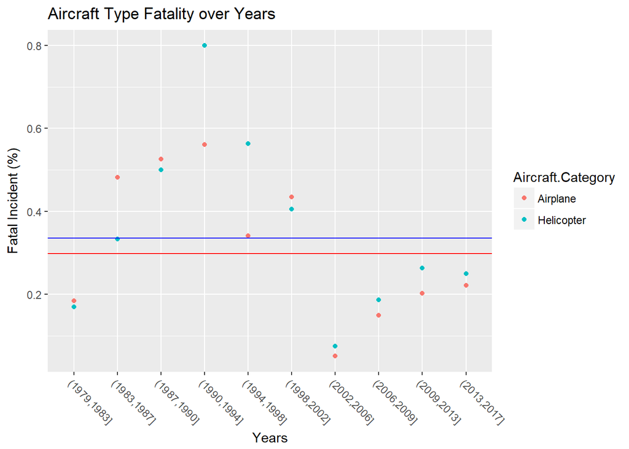

```r
alt_av_tab_3 %>%
  filter(Aircraft.Category == "Airplane"| Aircraft.Category == "Helicopter") %>%
  ggplot(aes(x=period, y=Percent.Fatal, color=Aircraft.Category)) +
  geom_point() +
  geom_hline(aes(yintercept=median(Percent.Fatal)), color="red") +
  geom_hline(aes(yintercept=mean(Percent.Fatal)), color="blue") +
  labs(title="Aircraft Type Fatality over Years",
          x="Years", y="Fatal Incident (%)") +
  theme(axis.text.x = element_text(angle = -45, hjust = 0))
```

```r
n <- 10
pa <- .48
var_xbar <- pa * (1-pa) / n

p_bhat <- .75

res <- pnorm(p_bhat, mean=pa, sd=sqrt(var_xbar), lower.tail = FALSE)
res
```

```
## [1] 0.04372569
```

## Analysis through Machine Learning

Another way to analyze the data and test the hypothesis is through machine learning where normally we will create two sets of data, one for testing and the other for training. However, due to the nature of our data we are going to simplify this analysis by using linear regression over the Years and distinguish how Fatalities are either increasing or decreasing in the last decade compared to Airplanes. Here we will be able to determine exactly how much safer airplanes are compared to helicopters by the difference in coefficients between the two Aircraft Categories.

Further more, we can do some statistical analysis to see just how accurate the coefficients are and whether there could be room for error if we were to say predict a trend in the dangers of one Aircraft.Type over another.

```r
alt_av_tab_4 <- av_cat_clean %>%
  filter(Injury.Severity != "Unavailable") %>%
  group_by(Aircraft.Category, Year) %>%
  count(Injury.Severity) %>%
  mutate(Total.Incidents=n)

alt_av_tab_4$Severity.Fatal[alt_av_tab_4$Injury.Severity == "Fatal"] <- alt_av_tab_4$Total.Incidents[alt_av_tab_4$Injury.Severity == "Fatal"]

alt_av_tab_4$Severity.Incident[alt_av_tab_4$Injury.Severity == "Incident"] <- alt_av_tab_4$Total.Incidents[alt_av_tab_4$Injury.Severity == "Incident"]

alt_av_tab_4$Severity.Non_Fatal[alt_av_tab_4$Injury.Severity == "Non-Fatal"] <- alt_av_tab_4$Total.Incidents[alt_av_tab_4$Injury.Severity == "Non-Fatal"]

alt_av_tab_4 <- alt_av_tab_4 %>%
  select(Aircraft.Category,Year,Severity.Fatal,Severity.Non_Fatal, Severity.Incident) %>%
  summarize_all(funs(sum(., na.rm = TRUE))) %>%
  mutate(Percent.Fatal = (Severity.Fatal/(Severity.Non_Fatal+Severity.Incident+Severity.Fatal)))

av_fit <- lm(Percent.Fatal~Year+Aircraft.Category, data = alt_av_tab_4)

av_fit
```

```
##
## Call:
## lm(formula = Percent.Fatal ~ Year + Aircraft.Category, data = alt_av_tab_4)
##
## Coefficients:
##                        (Intercept)                                Year
##                           7.941585                           -0.003816
##           Aircraft.CategoryBalloon              Aircraft.CategoryBlimp
##                          -0.217080                           -0.283781
##            Aircraft.CategoryGlider          Aircraft.CategoryGyrocraft
##                          -0.169972                           -0.076209
##         Aircraft.CategoryGyroplane         Aircraft.CategoryHelicopter
##                          -0.153104                            0.032388
##      Aircraft.CategoryPowered-Lift  Aircraft.CategoryPowered Parachute
##                          -0.282827                           -0.146839
##            Aircraft.CategoryRocket         Aircraft.CategoryUltralight
##                           0.743885                           -0.011572
##      Aircraft.CategoryWeight-Shift
##                          -0.054718
```

```r
av_fit_stats <- av_fit %>%
  tidy()

av_fit_stats %>% knitr::kable()
```

| term | estimate | std.error | statistic | p.value |
| --- | --- | --- | --- | --- |
| (Intercept) | 7.9415851 | 4.0442017 | 1.9636966 | 0.0514142 |
| Year | -0.0038160 | 0.0020231 | -1.8862403 | 0.0611955 |
| Aircraft.CategoryBalloon | -0.2170802 | 0.0692561 | -3.1344572 | 0.0020716 |
| Aircraft.CategoryBlimp | -0.2837812 | 0.1182990 | -2.3988476 | 0.0176748 |
| Aircraft.CategoryGlider | -0.1699722 | 0.0658110 | -2.5827313 | 0.0107584 |
| Aircraft.CategoryGyrocraft | -0.0762091 | 0.0704281 | -1.0820850 | 0.2809512 |
| Aircraft.CategoryGyroplane | -0.1531035 | 0.1022634 | -1.4971489 | 0.1364558 |
| Aircraft.CategoryHelicopter | 0.0323880 | 0.0550157 | 0.5887044 | 0.5569451 |
| Aircraft.CategoryPowered-Lift | -0.2828272 | 0.1347059 | -2.0995913 | 0.0374391 |
| Aircraft.CategoryPowered Parachute | -0.1468391 | 0.0839921 | -1.7482493 | 0.0824668 |
| Aircraft.CategoryRocket | 0.7438849 | 0.2277851 | 3.2657319 | 0.0013530 |
| Aircraft.CategoryUltralight | -0.0115718 | 0.0743932 | -0.1555493 | 0.8765974 |
| Aircraft.CategoryWeight-Shift | -0.0547179 | 0.0839921 | -0.6514649 | 0.5157433 |

## Conclusions

So now we can see clearly how all aircraft compare to Airplanes which is facinating as we notice are able to notice that Rockets has the highest coefficient estimate, something we were not able to see in the previous analysis. In real life, what this means is that when something goes wrong in a rocket, it is mostly likely going to be a catestrophic event. Similarly, but not as drastically, we see how Helicopters are slightly more dangerous than airplanes which was something we were able to hypothesize given the our preliminary data analysis.

Finally, you should know that though the data is sound, the analysis is up for interpretation and different regressions will provide different statistics that change how the data is modeled. Therefore, just because my results say that helicopters are more dangerous than airplanes may not paint the whole picture, but here I have laid out how I have come to my conclusions so that anyone can come and prove it for themselves or see errors that can be fixed by more rigorous analysis and regression.